# derfinder basic results exploration

Project: report.

# Introduction

This report is meant to help explore the results of the `derfinder` ([Collado-Torres, Frazee, Love, Irizarry, et al., 2015](http://www.biorxiv.org/content/early/2015/02/19/015370.abstract)) package and was generated using `regionReport` ([Collado-Torres, Jaffe, and Leek, 2015](http://www.bioconductor.org/packages/release/bioc/html/regionReport.html)) package. While the report is rich, it is meant to just start the exploration of the results and exemplify some of the code used to do so. You will most likely need a more in-depth analysis for your specific data set.

Most plots were made with using `ggplot2` ([Wickham, 2009](http://had.co.nz/ggplot2/book)).

# Quality checks

## P-values

Theoretically, the p-values should be uniformly distributed between 0 and 1.

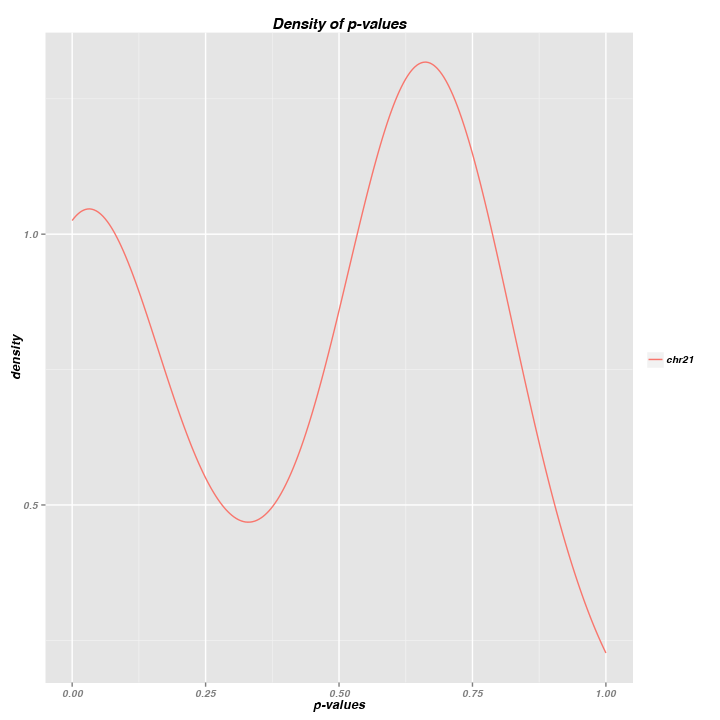

```r
##    Min. 1st Qu.  Median    Mean 3rd Qu.    Max.
## 0.01887 0.01887 0.62260 0.40650 0.62260 0.96230
```

This is the numerical summary of the distribution of the p-values.

## Q-values

```r
##    Min. 1st Qu.  Median    Mean 3rd Qu.    Max.
## 0.01338 0.01338 0.20570 0.13420 0.20570 0.24810
```

This is the numerical summary of the distribution of the q-values.

| Cut | Count |
| --- | --- |
| 0.0001 | 0 |
| 0.0010 | 0 |
| 0.0100 | 0 |
| 0.0250 | 12 |
| 0.0500 | 12 |
| 0.1000 | 12 |
| 0.2000 | 15 |
| 0.3000 | 33 |
| 0.4000 | 33 |
| 0.5000 | 33 |
| 0.6000 | 33 |
| 0.7000 | 33 |
| 0.8000 | 33 |
| 0.9000 | 33 |
| 1.0000 | 33 |

This table shows the number of candidate Differentially Expressed Regions (DERs) with q-value less or equal than some commonly used cutoff values.

## FWER adjusted P-values

This is the numerical summary of the distribution of the q-values. Skipped because there are no FWER-adjusted P-values.

This table shows the number of candidate Differentially Expressed Regions (DERs) with FWER adjusted p-values less or equal than some commonly used cutoff values. Skipped because there are no FWER-adjusted P-values.

## Region width

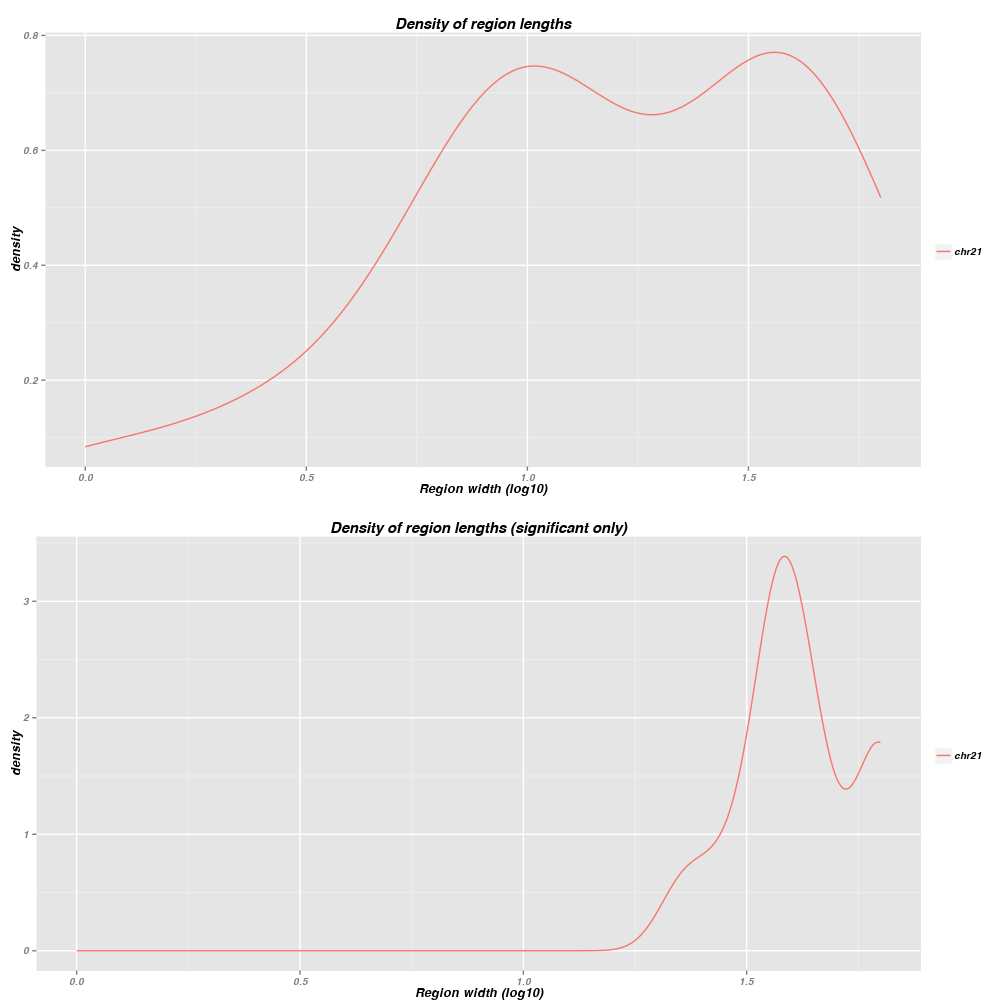

This plot shows the density of the region lengths for all regions. The bottom panel is restricted to significant regions (q-value < 0.1)

## Region Area

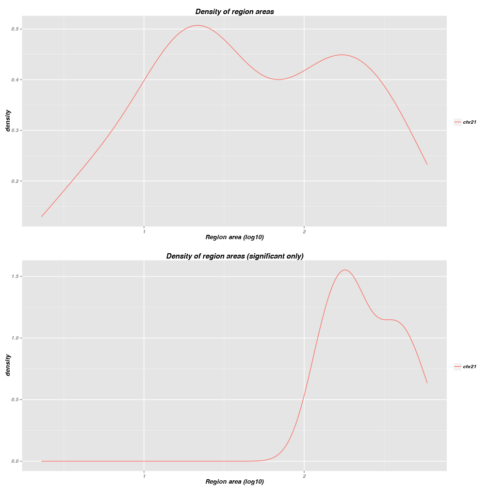

This plot shows the density of the region areas for all regions. The bottom panel is restricted to significant regions (q-value < 0.1)

## Null regions: width and area

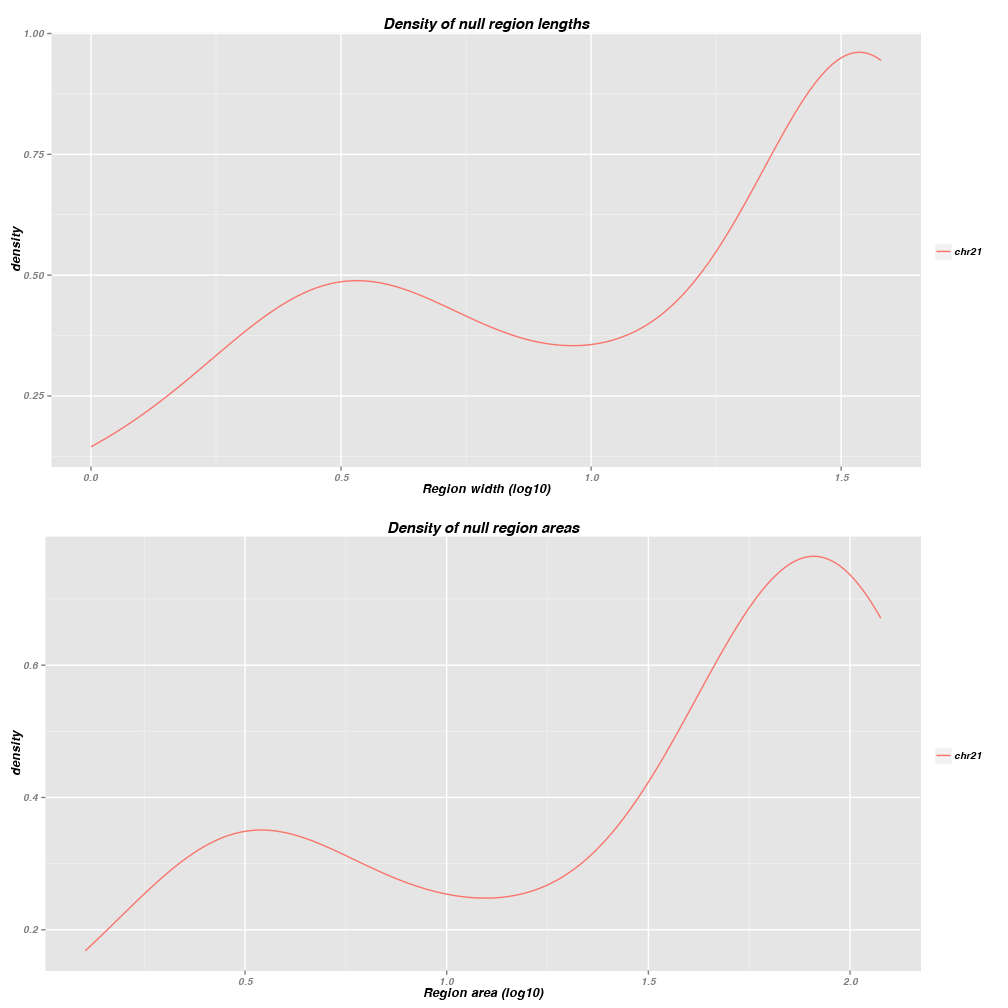

This plot shows the density of the null region lengths and areas. There were a total of 52 null regions.

## Mean coverage

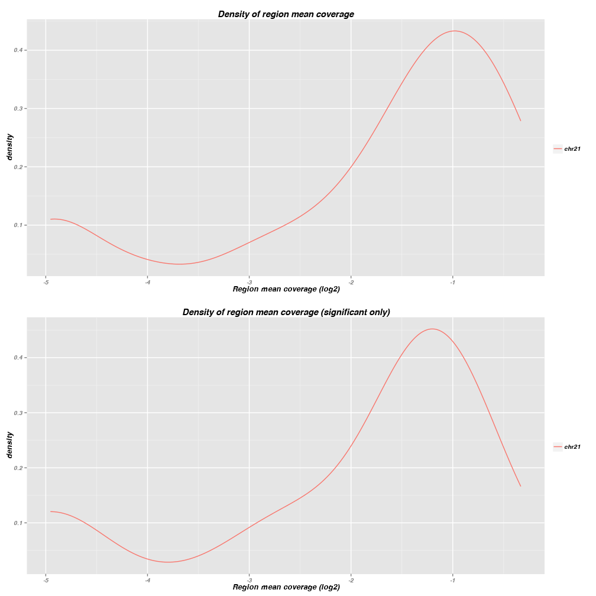

This plot shows the density of the region mean coverage for all regions. The bottom panel is restricted to significant regions (q-value < 0.1)

## Mean coverage vs fold change

The following plots are [MA](http://en.wikipedia.org/wiki/MA_plot)-style plots comparing each group vs the first one. The mean coverage is calculated using only two groups at a time and is weighted according to the number of samples on each group. Note that the mean coverage and fold change as calculated here do not taking into account the library sizes.

These plots are only shown when there are two or more groups. A total of 1 plot(s) were made.

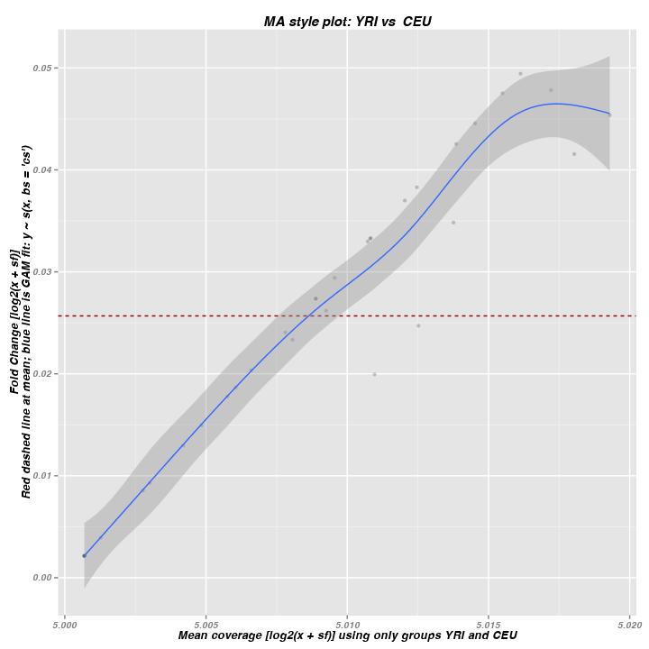

# Genomic overview

The following plots were made using `ggbio` (Yin, Cook, and Lawrence, 2012) which in turn uses `ggplot2` ([Wickham, 2009](http://had.co.nz/ggplot2/book)). For more details check `plotOverview` in `derfinder` ([Collado-Torres, Frazee, Love, Irizarry, et al., 2015](http://www.biorxiv.org/content/early/2015/02/19/015370.abstract)).

## Q-values

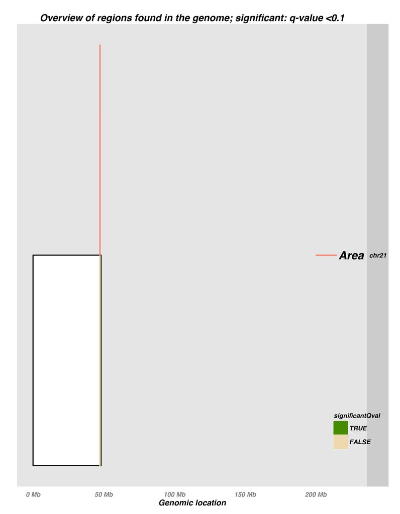

This plot shows the genomic locations of the **candidate** regions found in the analysis. The significant regions (q-value less than 0.1) are highlighted and the area of the regions is shown on top of each chromosome. Note that the area is in a relative scale.

## Annotation

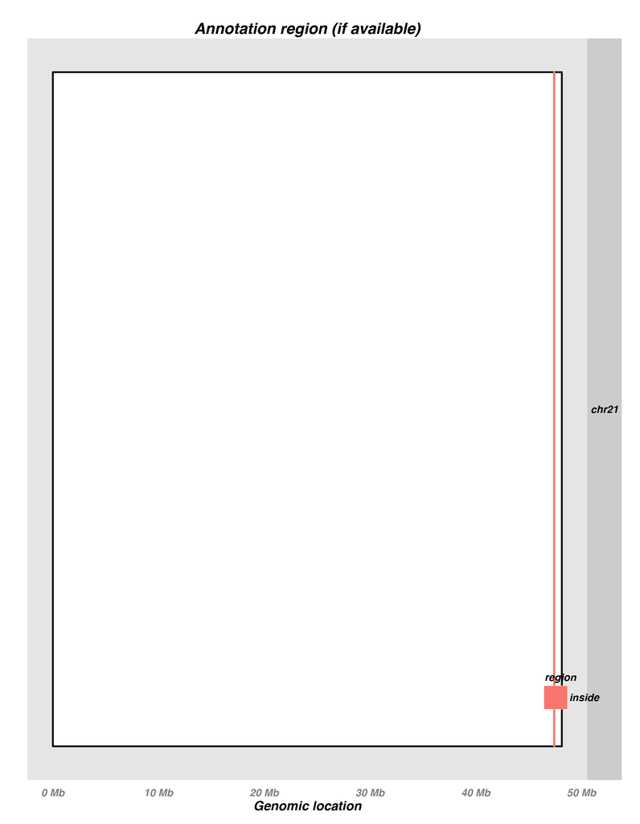

This genomic overview plot shows the annotation region type for the **candidate** regions. Note that the regions are shown only if the annotation information is available. Below is a table of the actual number of results per annotation region type.

| Region | Count |
| --- | --- |
| upstream | 0 |
| promoter | 0 |
| overlaps 5' | 0 |
| inside | 33 |
| overlaps 3' | 0 |
| close to 3' | 0 |
| downstream | 0 |
| covers | 0 |
| NA | 0 |

## Annotation (significant)

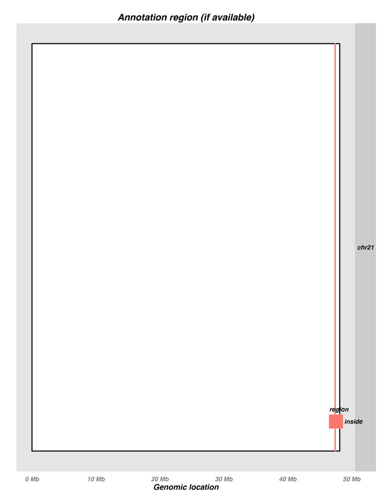

This genomic overview plot shows the annotation region type for the **candidate** regions that have a q-value less than 0.1. Note that the regions are shown only if the annotation information is available.

# Best regions

## Plots

Below are the plots for the top 15 candidate DERs as ranked by area. For each plot, annotation is shown if the candidate DER has a minimum overlap of 20 base pairs with annotation information (strand specific). If present, exons are collapsed and shown in blue. Introns are shown in light blue. The title of each plot is composed of the name of the nearest annotation element, the distance to it, and whether the region of the genome the DER falls into; all three pieces of information are based on `bumphunter::annotateNearest()`.

The annotation depends on the Genomic State used. For details on which one was used for this report check the call to `mergeResults` in the reproducibility details.

[figure not shown]

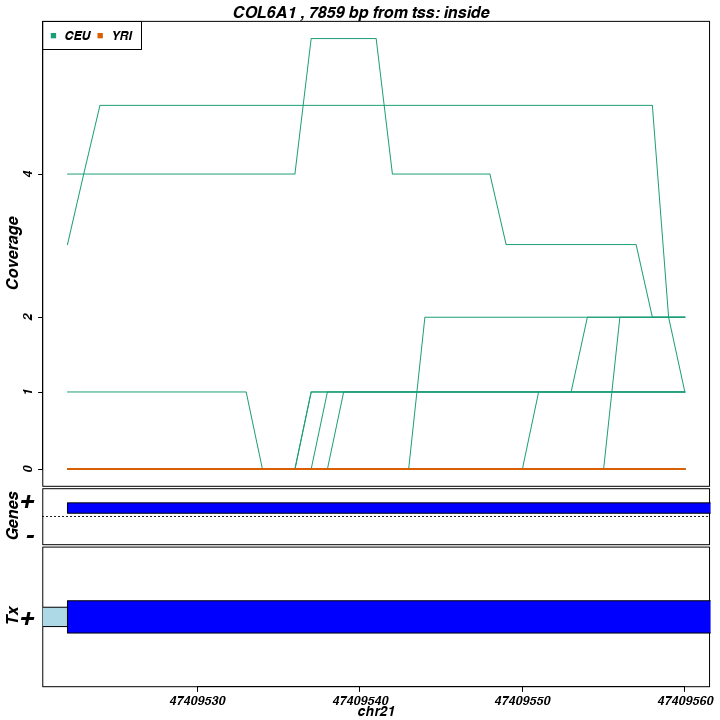

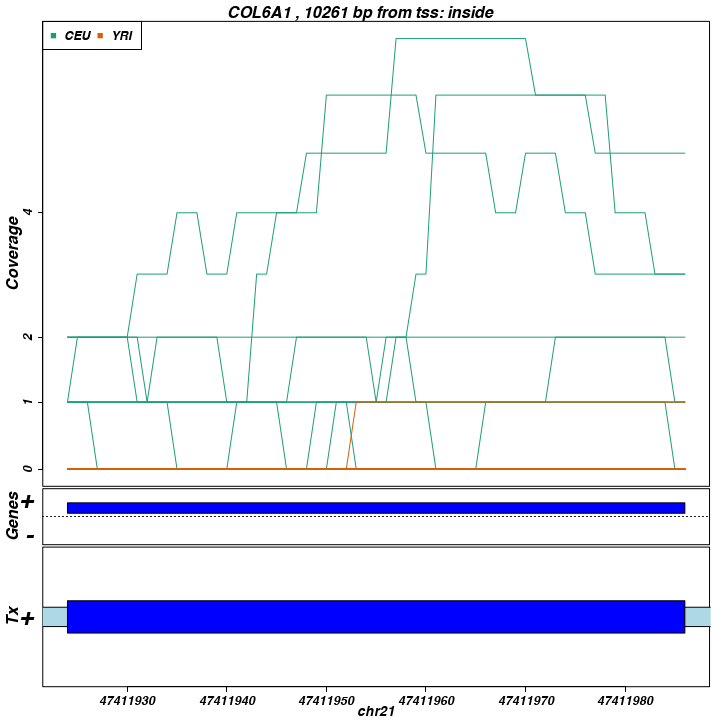

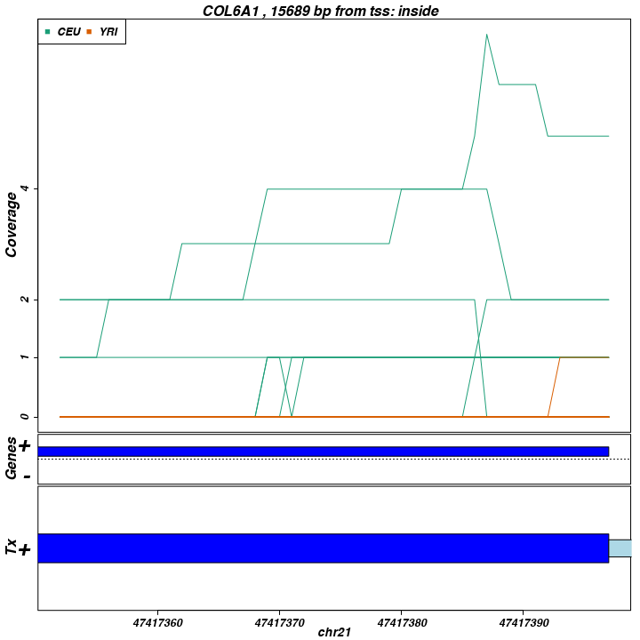

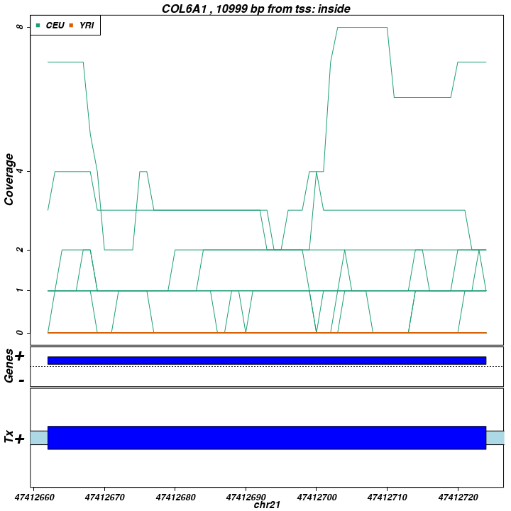

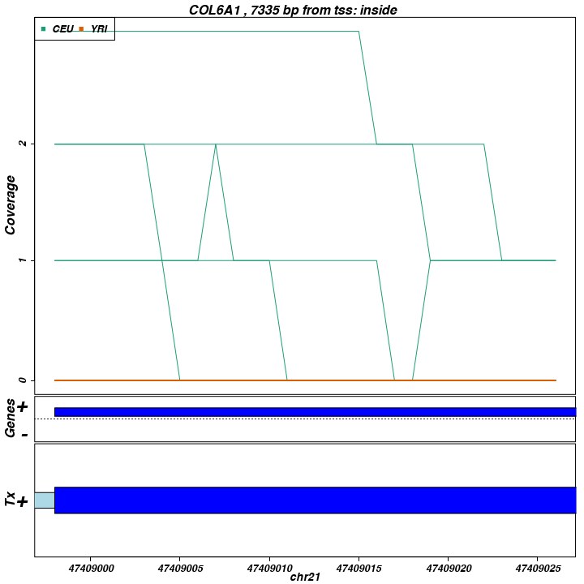

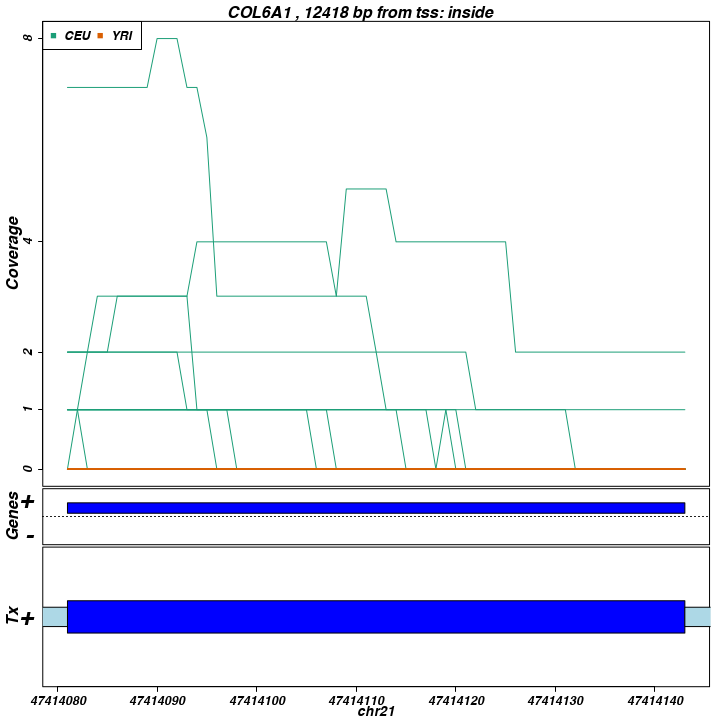

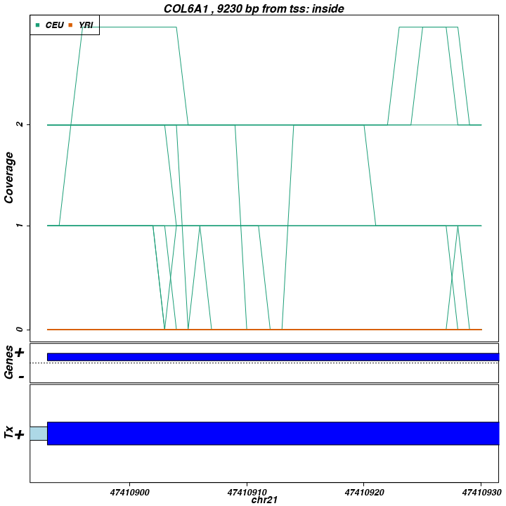

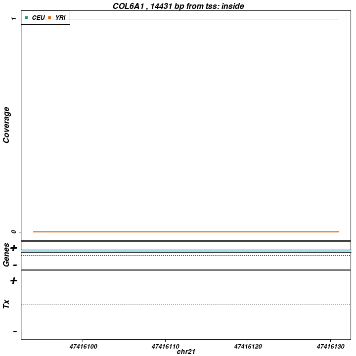

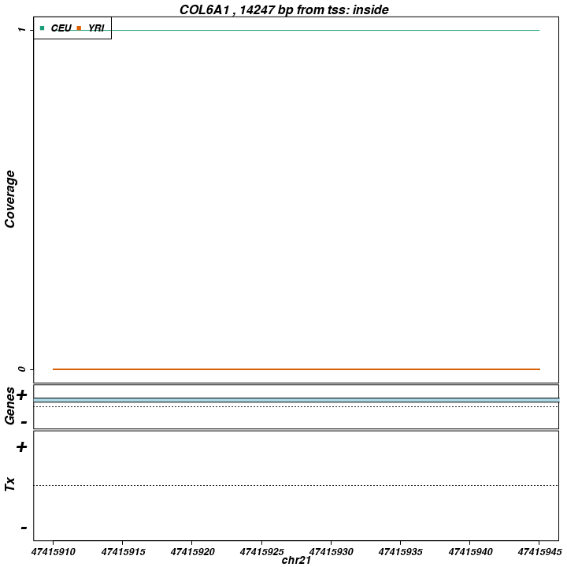

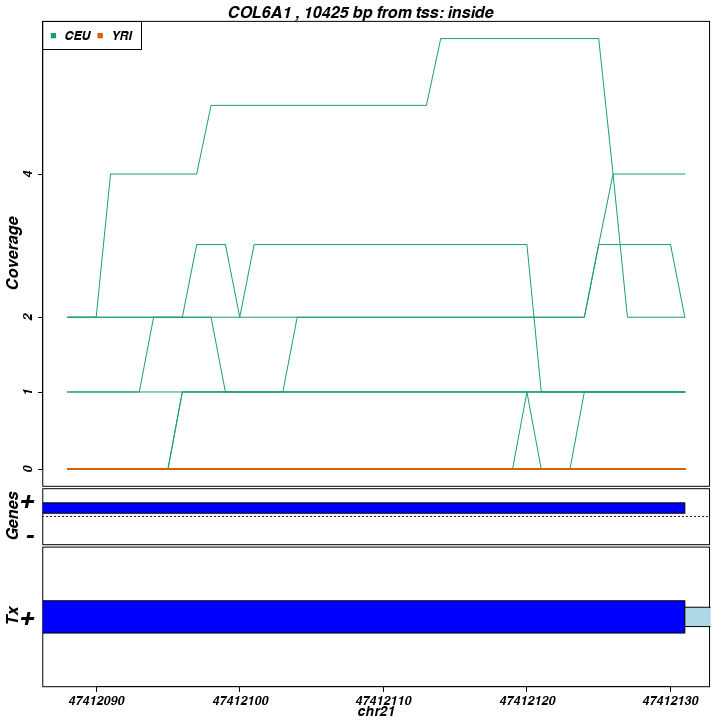

[figure not shown]

[5 more figures not shown]

Below is a table summarizing the number of genomic states per region.

| Number of Overlapping States | Frequency | State |
| --- | --- | --- |
| 0 | 22 | exon |
| 1 | 11 | exon |
| 0 | 33 | intergenic |
| 0 | 30 | intron |
| 1 | 3 | intron |

## Region information

Below is an interactive table with the top 33 regions (out of 33) as ranked by area. Inf and -Inf are shown as 1e100 and -1e100 respectively.

seqnames

start

end

width

strand

value

area

indexStart

indexEnd

cluster

clusterL

meanCoverage

meanCEU

meanYRI

log2FoldChangeYRIvsCEU

pvalues

significant

qvalues

significantQval

name

annotation

description

region

distance

subregion

insidedistance

exonnumber

nexons

UTR

annoStrand

geneL

codingL

chr21

47409522

47409560

39

15.053644

587.092111

128

166

3

167

0.4152192

0.6129426

0.0000000

-1.000000e+100

0.0188679

TRUE

0.0133769

TRUE

COL6A1

NM_001848 NP_001839

inside exon

inside

7859

inside exon

0

10

35

inside transcription region

23300

22162

2

chr21

47411924

47411986

63

7.096704

447.092322

618

680

6

389

0.5847414

0.8374906

0.0539683

-3.955890e+00

0.0188679

TRUE

0.0133769

TRUE

COL6A1

NM_001848 NP_001839

inside exon

inside

10261

inside exon

0

16

35

inside transcription region

23300

22162

3

chr21

47417352

47417397

46

8.778446

403.808491

1292

1337

10

338

0.3646564

0.5331263

0.0108696

-5.616111e+00

0.0188679

TRUE

0.0133769

TRUE

COL6A1

NM_001848 NP_001839

inside exon

inside

15689

inside exon

0

21

35

inside transcription region

23300

22162

4

chr21

47412662

47412724

63

5.671216

357.286601

843

905

7

63

0.5012801

0.7399849

0.0000000

-1.000000e+100

0.0188679

TRUE

0.0133769

TRUE

COL6A1

NM_001848 NP_001839

inside exon

inside

10999

inside exon

0

19

35

inside transcription region

23300

22162

5

chr21

47408998

47409026

29

10.685252

309.872297

69

97

2

232

0.1957731

0.2889984

0.0000000

-1.000000e+100

0.0188679

TRUE

0.0133769

TRUE

COL6A1

NM_001848 NP_001839

inside exon

inside

7335

inside exon

0

9

35

inside transcription region

23300

22162

6

chr21

47414081

47414143

63

3.308408

208.429718

994

1056

8

63

0.3645673

0.5381708

0.0000000

-1.000000e+100

0.0188679

TRUE

0.0133769

TRUE

COL6A1

NM_001848 NP_001839

inside exon

inside

12418

inside exon

0

20

35

inside transcription region

23300

22162

7

chr21

47410893

47410930

38

5.452573

207.197772

407

444

5

269

0.4151104

0.6127820

0.0000000

-1.000000e+100

0.0188679

TRUE

0.0133769

TRUE

COL6A1

NM_001848 NP_001839

inside exon

inside

9230

inside exon

0

15

35

inside transcription region

23300

22162

8

chr21

47416094

47416131

38

5.109484

194.160408

1165

1202

9

222

0.0322581

0.0476190

0.0000000

-1.000000e+100

0.0188679

TRUE

0.0133769

TRUE

COL6A1

NM_001848 NP_001839

inside intron

inside

14431

inside intron

1204

21

35

inside transcription region

23300

22162

9

chr21

47415910

47415945

36

5.109484

183.941439

1129

1164

9

222

0.0322581

0.0476190

0.0000000

-1.000000e+100

0.0188679

TRUE

0.0133769

TRUE

COL6A1

NM_001848 NP_001839

inside intron

inside

14247

inside intron

1390

21

35

inside transcription region

23300

22162

10

chr21

47412088

47412131

44

3.344261

147.147470

691

734

6

389

0.4464809

0.6590909

0.0000000

-1.000000e+100

0.0188679

TRUE

0.0133769

TRUE

COL6A1

NM_001848 NP_001839

inside exon

inside

10425

inside exon

0

17

35

inside transcription region

23300

22162

11

chr21

47412277

47412312

36

3.575484

128.717432

735

770

6

389

0.5053763

0.7460317

0.0000000

-1.000000e+100

0.0188679

TRUE

0.0133769

TRUE

COL6A1

NM_001848 NP_001839

inside exon

inside

10614

inside exon

0

18

35

inside transcription region

23300

22162

12

chr21

47409034

47409056

23

5.557125

127.813881

105

127

2

232

0.1402525

0.2070393

0.0000000

-1.000000e+100

0.0188679

TRUE

0.0133769

TRUE

COL6A1

NM_001848 NP_001839

overlaps exon downstream

inside

7371

overlaps exon downstream

0

9

35

inside transcription region

23300

22162

13

chr21

47417614

47417650

37

2.849383

105.427164

1338

1374

10

338

0.4027899

0.5469755

0.1000000

-2.451476e+00

0.2452830

FALSE

0.1605224

FALSE

COL6A1

NM_001848 NP_001839

inside exon

inside

15951

inside exon

0

22

35

inside transcription region

23300

22162

14

chr21

47410934

47410955

22

3.652389

80.352551

448

469

5

269

0.3079179

0.4545455

0.0000000

-1.000000e+100

0.3207547

FALSE

0.1819254

FALSE

COL6A1

NM_001848 NP_001839

inside exon

inside

9271

inside exon

0

15

35

inside transcription region

23300

22162

15

chr21

47407554

47407568

15

4.704220

70.563298

18

32

1

32

0.2688172

0.3968254

0.0000000

-1.000000e+100

0.3207547

FALSE

0.1819254

FALSE

COL6A1

NM_001848 NP_001839

inside exon

inside

5891

inside exon

0

8

35

inside transcription region

23300

22162

16

chr21

47408825

47408860

36

1.161740

41.822652

33

68

2

232

0.0322581

0.0476190

0.0000000

-1.000000e+100

0.5849057

FALSE

0.2056693

FALSE

COL6A1

NM_001848 NP_001839

inside intron

inside

7162

inside intron

138

9

35

inside transcription region

23300

22162

17

chr21

47410702

47410714

13

2.378483

30.920276

368

380

5

269

0.5831266

0.8608059

0.0000000

-1.000000e+100

0.6226415

FALSE

0.2056693

FALSE

COL6A1

NM_001848 NP_001839

inside exon

inside

9039

inside exon

0

14

35

inside transcription region

23300

22162

18

chr21

47410292

47410305

14

2.166562

30.331874

227

240

4

159

0.7672811

1.1156463

0.0357143

-4.965235e+00

0.6226415

FALSE

0.2056693

FALSE

COL6A1

NM_001848 NP_001839

inside exon

inside

8629

inside exon

0

13

35

inside transcription region

23300

22162

19

chr21

47410188

47410198

11

2.569046

28.259510

216

226

4

159

0.7947214

1.1255411

0.1000000

-3.492547e+00

0.6226415

FALSE

0.2056693

FALSE

COL6A1

NM_001848 NP_001839

inside exon

inside

8525

inside exon

0

12

35

inside transcription region

23300

22162

20

chr21

47410731

47410740

10

2.698208

26.982075

397

406

5

269

0.5064516

0.7476190

0.0000000

-1.000000e+100

0.6226415

FALSE

0.2056693

FALSE

COL6A1

NM_001848 NP_001839

inside exon

inside

9068

inside exon

0

14

35

inside transcription region

23300

22162

21

chr21

47407537

47407542

6

4.061822

24.370932

1

6

1

32

0.0591398

0.0873016

0.0000000

-1.000000e+100

0.6226415

FALSE

0.2056693

FALSE

COL6A1

NM_001848 NP_001839

inside exon

inside

5874

inside exon

0

8

35

inside transcription region

23300

22162

22

chr21

47410687

47410698

12

1.773713

21.284559

353

364

5

269

0.6801075

1.0039683

0.0000000

-1.000000e+100

0.6226415

FALSE

0.2056693

FALSE

COL6A1

NM_001848 NP_001839

inside exon

inside

9024

inside exon

0

14

35

inside transcription region

23300

22162

23

chr21

47410175

47410184

10

1.857995

18.579952

203

212

4

159

0.7354839

1.0380952

0.1000000

-3.375867e+00

0.6226415

FALSE

0.2056693

FALSE

COL6A1

NM_001848 NP_001839

inside exon

inside

8512

inside exon

0

12

35

inside transcription region

23300

22162

24

chr21

47410314

47410322

9

2.063009

18.567083

249

257

4

159

0.6487455

0.9576720

0.0000000

-1.000000e+100

0.6226415

FALSE

0.2056693

FALSE

COL6A1

NM_001848 NP_001839

inside exon

inside

8651

inside exon

0

13

35

inside transcription region

23300

22162

25

chr21

47410716

47410726

11

1.631502

17.946526

382

392

5

269

0.5630499

0.8311688

0.0000000

-1.000000e+100

0.6226415

FALSE

0.2056693

FALSE

COL6A1

NM_001848 NP_001839

inside exon

inside

9053

inside exon

0

14

35

inside transcription region

23300

22162

26

chr21

47412078

47412083

6

2.293818

13.762909

681

686

6

389

0.4139785

0.6031746

0.0166667

-5.177538e+00

0.6981132

FALSE

0.2056693

FALSE

COL6A1

NM_001848 NP_001839

inside exon

inside

10415

inside exon

0

17

35

inside transcription region

23300

22162

27

chr21

47417655

47417662

8

1.570295

12.562357

1379

1386

10

338

0.2822581

0.4166667

0.0000000

-1.000000e+100

0.6981132

FALSE

0.2056693

FALSE

COL6A1

NM_001848 NP_001839

inside exon

inside

15992

inside exon

0

22

35

inside transcription region

23300

22162

28

chr21

47410327

47410333

7

1.521231

10.648620

262

268

4

159

0.7557604

1.1156463

0.0000000

-1.000000e+100

0.6981132

FALSE

0.2056693

FALSE

COL6A1

NM_001848 NP_001839

inside exon

inside

8664

inside exon

0

13

35

inside transcription region

23300

22162

29

chr21

47417666

47417672

7

1.215518

8.508629

1390

1396

10

338

0.2258065

0.3333333

0.0000000

-1.000000e+100

0.7358491

FALSE

0.2056693

FALSE

COL6A1

NM_001848 NP_001839

inside exon

inside

16003

inside exon

0

22

35

inside transcription region

23300

22162

30

chr21

47409685

47409688

4

1.215855

4.863420

192

195

3

167

0.4758065

0.6547619

0.1000000

-2.710970e+00

0.7735849

FALSE

0.2056693

FALSE

COL6A1

NM_001848 NP_001839

inside exon

inside

8022

inside exon

0

11

35

inside transcription region

23300

22162

31

chr21

47417335

47417337

3

1.591623

4.774869

1275

1277

10

338

0.1290323

0.1904762

0.0000000

-1.000000e+100

0.7735849

FALSE

0.2056693

FALSE

COL6A1

NM_001848 NP_001839

inside exon

inside

15672

inside exon

0

21

35

inside transcription region

23300

22162

32

chr21

47418068

47418068

1

3.997655

3.997655

1434

1434

11

1

0.0322581

0.0476190

0.0000000

-1.000000e+100

0.7735849

FALSE

0.2056693

FALSE

COL6A1

NM_001848 NP_001839

inside exon

inside

16405

inside exon

0

23

35

inside transcription region

23300

22162

33

chr21

47410311

47410312

2

1.143626

2.287252

246

247

4

159

0.7258065

1.0714286

0.0000000

-1.000000e+100

0.9622642

FALSE

0.2480801

FALSE

COL6A1

NM_001848 NP_001839

inside exon

inside

8648

inside exon

0

13

35

inside transcription region

23300

22162

# Best region clusters

The following plots were made using `ggbio` (Yin, Cook, and Lawrence, 2012) which in turn uses `ggplot2` ([Wickham, 2009](http://had.co.nz/ggplot2/book)). For more details check `plotCluster()` in `derfinder` ([Collado-Torres, Frazee, Love, Irizarry, et al., 2015](http://www.biorxiv.org/content/early/2015/02/19/015370.abstract)).

## Plots

Below are the best 2 region clusters ordered by cluster area (sum of the area of regions inside a cluster). The region with the highest area in the cluster is shown with a red bar.

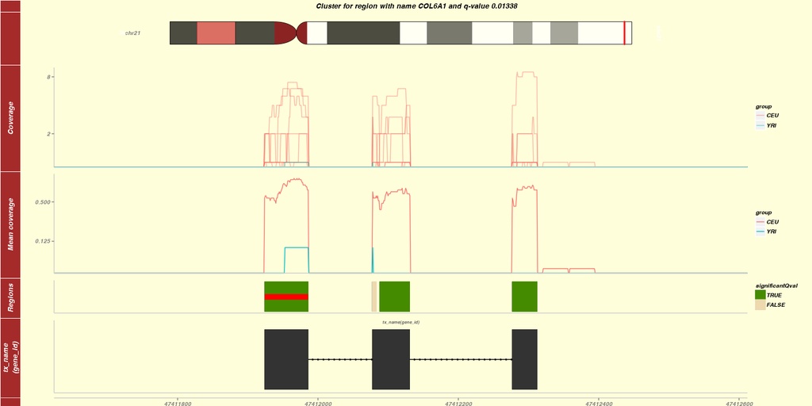

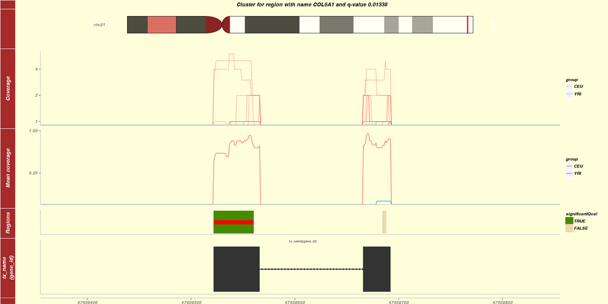

# Permutations

Below is the information on how the samples were permutted.

## Summary

```r
##       CEU             YRI
##  Min.   : 6.00   Min.   :4.0
##  1st Qu.: 8.25   1st Qu.:4.5
##  Median :10.50   Median :5.0
##  Mean   :10.50   Mean   :5.0
##  3rd Qu.:12.75   3rd Qu.:5.5
##  Max.   :15.00   Max.   :6.0
```

This table shows the summary per group of how many samples were assigned to the group. It can be used for fast detection of anomalies. Also note that 0 permutations out of 1 total permutations resulted in the same grouping as in the original observed data.

Note that in `derfinder` the re-sampling of the samples is done without replacement. This is done to avoid singular model matrices. While the sample balance is the same across the permutations, what changes are the adjusted variables (including the column medians).

## Interactive

The following table shows how the group labels were permuted. This can be useful to detect whether a permutation in particular had too many samples of a group labeled as another group, meaning that the resulting permuted group label resulted in pretty much a name change.

| permutation | group | CEU | YRI |
| --- | --- | --- | --- |
| 1 | CEU | 15 | 6 |
| 1 | YRI | 6 | 4 |